# Project 1: Ikea Furniture

Sofia Hirschmann

1 March 2021

```r
library(tidyverse)
library(mosaic)
library(ggplot2)
```

```r
ikea_new = ikea %>%
  filter(category %in% c("Beds", "Chairs", "Bookcases & shelving units", "Chests of drawers & drawer units", "Sofas & armchairs", "Tables & desks", "TV & media furniture")) %>%
  rename(Category = category)

ikea_neww = ikea_new %>%
  filter(price <= 3000)
```

# **Plan Your Apartment Furnishing**

##### By: Sofia Hirschmann

###### March 1, 2021

It can seem daunting to begin the process of purchasing the furniture needed to fill a new apartment. There are so many options out there in terms of price and quality. The multinational furniture retail company, **Ikea**, is well known and has been a top choice for young adults since 2008. Their products are functional and sustainable but most importantely they are *affordable*.

For me, being a college student that plans to move into their first apartment soon, there are two key questions that I find myself asking, as I begin my move, in preparation.

**How much should I be budgeting for these purchases?**

**Are these products purchasable online?**

## Budgeting

Budgeting is especially important for the younger members of society when planning a significant change in life. The box plot below depicts the distribution of furniture prices by category. The data for this display is pulled from an Ikea dataset published on the TidyTuesday site in November of 2020.

This display clearly shows that if someone is planning on furnishing their house using Ikea furniture, the two most significant categories that they will have to budget for are **Beds** with a median price of *$1093.5* and **Sofas/armchairs** with a median price of *$1268.5*.

Additionally, all of the categories in the boxplot below, besides **Drawers**, display a significantly large range in pricing. This indicates that there are most likely a range in options, quality and style, depending on the price that you are willing to invest in your furnishing.

```r
favstats(price~category, data = ikea_new)
```

[output not shown]

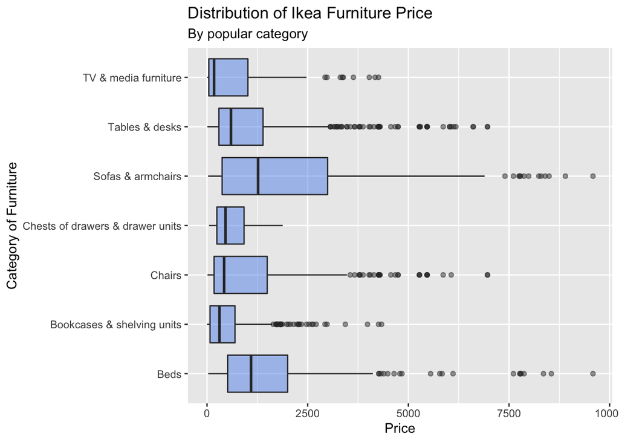

```r
ggplot(data = ikea_new, aes(x = price, y = Category)) +
  geom_boxplot(fill = 'cornflowerblue', alpha = 0.5) +
  labs(x = "Price", y = "Category of Furniture", title = "Distribution of Ikea Furniture Price", subtitle = "By popular category") +
  theme_grey()
```

It is always helpful to know how scarce or plentiful your options are when budget planning. The histograms below are organized, again, by furniture category, as well as by price up to *$3000*. The majority of overall prices, as seen in the boxplots, fall within this range. It is here where young adults will find their most affordable options. The histograms provide the amount of different models (on the left hand vertical axis) for each *$500* price range.

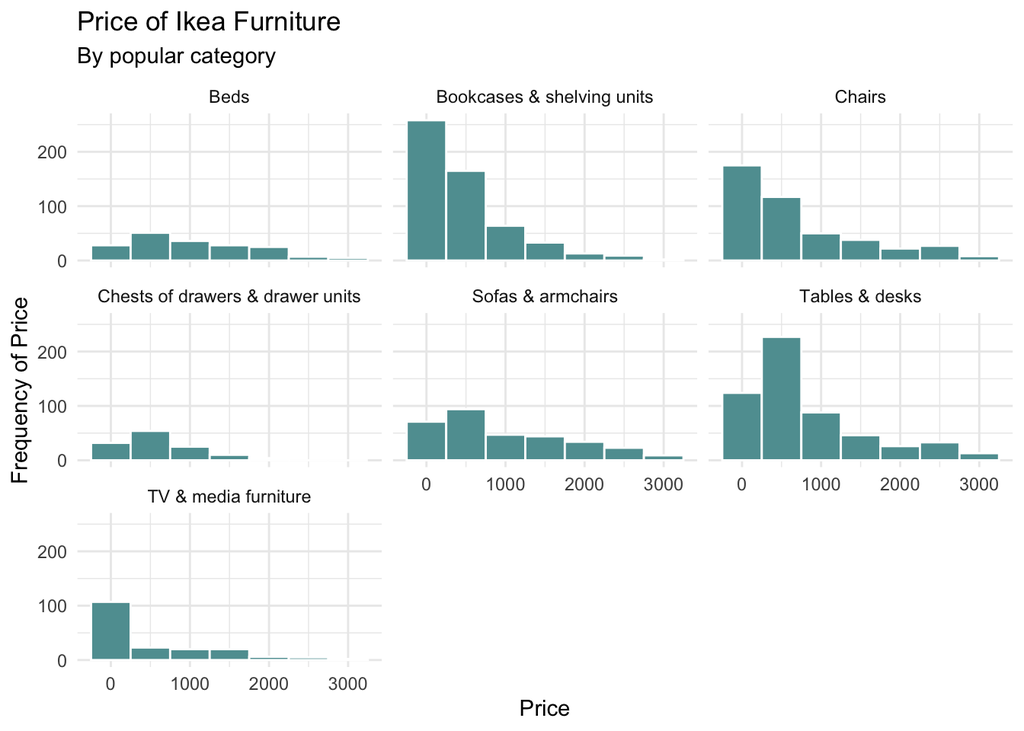

```r
ggplot(data = ikea_neww, aes(x = price)) +
  geom_histogram(color = "white", fill = "cadetblue", binwidth = 500) +
  facet_wrap( ~ Category) +
  labs(x = "Price", y = "Frequency of Price", title = "Price of Ikea Furniture", subtitle = "By popular category") +
  theme_minimal()
```

## Available Online?

Online shopping has been at an all time high. With the pandemic if it is possible to do something from home, many will utilize that option in order to avoid the risk that comes from being in the public. That risk is all the same even when it comes to shopping for furniture.

This display shows the proportion of each furniture category that is sold online. Each color represents a different category so that the proportion of each that is sold online can be easily assumed. We are in luck because, based on this dataset, although the quantity of model options available varies, every category is purchasable online.

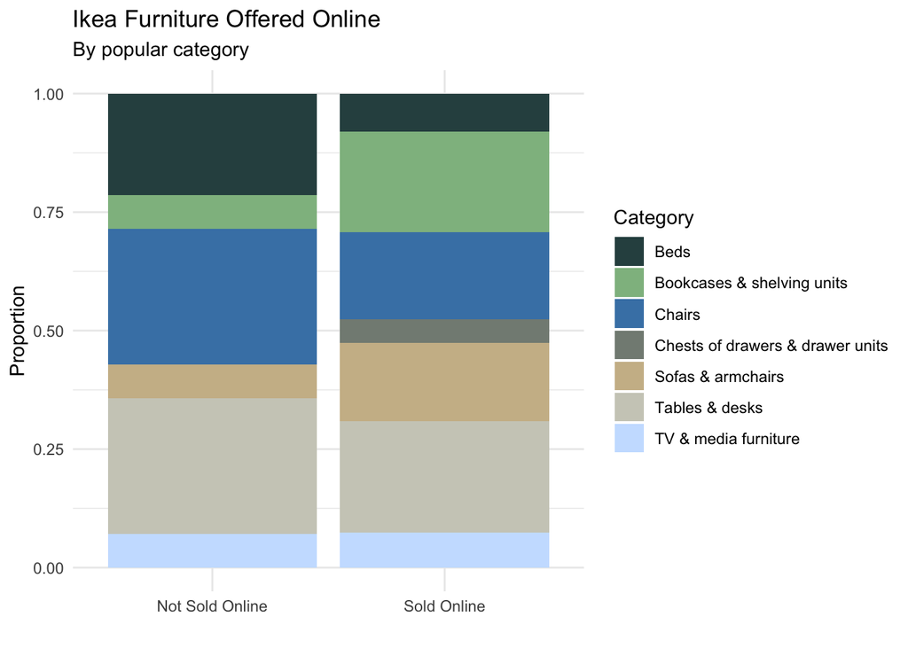

```r
ggplot(data = ikea_new, aes(x = sellable_online)) +
  geom_bar(aes(fill = Category), position = "fill") +
  labs(x = "", y = "Proportion", title = "Ikea Furniture Offered Online", subtitle = "By popular category") +
  scale_fill_manual(values = c("darkslategrey", "darkseagreen", "steelblue", "honeydew4", "wheat3", "ivory3", "lightsteelblue1")) +
  scale_x_discrete(labels = c("Not Sold Online", "Sold Online")) +
  theme_minimal()
```

## Conclusion

The price distrubutions show that no matter what your budget or style may be, chances are you will find a suitable option at Ikea. As seen in the final model, in addition to the convenience of options, there are a sgnificant proportion of those options available for online purchasing as well.

Note that although these findings come from an Ikea dataset, many of the patterns can still be helpful because they are likely also present in other big furniture companies, so feel free to apply the findings to a more relevant context.